# IRT Analysis of Midterm Exam 1

```r
# load all packages used in this exploratory analysis
library(knitr)
library(ggplot2)
library(mirt)
```

## Data Preprocessing

```r
# load data
data.raw <- read.csv('Midterm1.csv')
n<-106 # number of students
k<-30 #number of items
data.raw<-transform(data.raw, Student.Name = seq(1:n)) # replace names with numbers

answer.key<-c(3,4,3,1,4,2,2,1,3,2,
          3,4,2,2,2,4,2,1,2,1,
          3,1,2,2,4,3,3,3,1,2)
for (i in 1:n){
  data.raw[i,6:35]<-as.integer(data.raw[i,6:35]==answer.key)
    if (data.raw[i,5]!=sum(data.raw[i,6:35])){
      print(paste0("Calculated total score for student ",i," is not correct"))
      }
  }

data<-data.raw[,-c(seq(1:5),36,37)]
```

## Model Fit

The follwing lines fit a 2PL Model, an IRT model that specifies a unidimensional latent trait (i.e. abiliy) and two item paramters: discrimination *a* and difficulty *b*.

```r
(mod1 <- mirt(data, 1,itemtype='2PL',SE = TRUE,verbose = FALSE))
```

```
##
## Call:
## mirt(data = data, model = 1, itemtype = "2PL", SE = TRUE, verbose = FALSE)
##
## Full-information item factor analysis with 1 factor(s).
## Converged within 1e-04 tolerance after 39 EM iterations.
## mirt version: 1.6.1
## M-step optimizer: BFGS
## EM acceleration: Ramsay
## Number of rectangular quadrature: 41
##
## Information matrix estimated with method: crossprod
## Condition number of information matrix = 4007.764
## Second-order test: model is a possible local maximum
##
## Log-likelihood = -1242.234
## AIC = 2604.469; AICc = 2767.135
## BIC = 2764.275; SABIC = 2574.713
```

```r
# Item Parameter Estimates
coefficients<-matrix(unlist(coef(mod1,IRTpars = TRUE)[-31]),nrow=30,ncol=4,byrow=TRUE)[,-c(3,4)]
rownames(coefficients)<-colnames(data)
colnames(coefficients)<-c('discrimination','difficulty')
(coefficients)
```

```
##            discrimination difficulty
## Question1           1.381     -2.436
## Question2           0.600     -4.204
## Question3          -0.281     12.719
## Question4          -0.010    272.708
## Question5           0.490     -3.688
## Question6           0.526     -4.506
## Question7           0.026    -39.797
## Question8           0.024    -71.422
## Question9           0.592     -3.113
## Question10          0.268     -0.574
## Question11          1.370     -0.917
## Question12          1.721     -2.556
## Question13          1.021     -2.007
## Question14          0.611     -1.898
## Question15          1.318     -1.693
## Question16          0.632     -2.821
## Question17          2.011     -2.217
## Question18         -0.349     10.288
## Question19          0.872     -2.166
## Question20          0.862     -3.855
## Question21          0.943     -2.216
## Question22          0.125     -4.336
## Question23          0.921     -1.187
## Question24          0.565      0.213
## Question25          0.994     -1.236
## Question26          0.599     -4.425
## Question27          1.080     -1.452
## Question28          2.059     -1.970
## Question29          1.419     -1.906
## Question30          0.636      1.589
```

Transform coefficients into a standardized factor loading’s metric.

```r
summary(mod1)
```

```
##
## Factor loadings metric:
##                  F1       h2
## Question1   0.62996 3.97e-01
## Question2   0.33228 1.10e-01
## Question3  -0.16288 2.65e-02
## Question4  -0.00606 3.67e-05
## Question5   0.27682 7.66e-02
## Question6   0.29526 8.72e-02
## Question7   0.01513 2.29e-04
## Question8   0.01421 2.02e-04
## Question9   0.32869 1.08e-01
## Question10  0.15573 2.43e-02
## Question11  0.62708 3.93e-01
## Question12  0.71103 5.06e-01
## Question13  0.51435 2.65e-01
## Question14  0.33801 1.14e-01
## Question15  0.61231 3.75e-01
## Question16  0.34831 1.21e-01
## Question17  0.76335 5.83e-01
## Question18 -0.20107 4.04e-02
## Question19  0.45611 2.08e-01
## Question20  0.45171 2.04e-01
## Question21  0.48448 2.35e-01
## Question22  0.07340 5.39e-03
## Question23  0.47577 2.26e-01
## Question24  0.31486 9.91e-02
## Question25  0.50418 2.54e-01
## Question26  0.33212 1.10e-01
## Question27  0.53572 2.87e-01
## Question28  0.77078 5.94e-01
## Question29  0.64025 4.10e-01
## Question30  0.34986 1.22e-01
##
## SS loadings:  5.983
##
## Factor covariance:
##    F1
## F1  1
```

Estimate the vector of the estimated person ability scores *theta*.

```r
# person scores
theta <- fscores(mod1, method = 'MAP', full.scores = TRUE)
```

```r
IRT<-round(pnorm(data.raw$Z.Score),2)*100
CTT<-data.raw$Percentile
cbind(IRT,CTT)
```

```
##        IRT CTT
##   [1,]  80  76
##   [2,]  58  46
##   [3,]  97  99
##   [4,]  13  10
##   [5,]  45  35
##   [6,]  32  24
##   [7,]  45  35
##   [8,]  22  18
##   [9,]  70  58
##  [10,]  13  10
##  [11,]   7   6
##  [12,]  88  87
##  [13,]  58  46
##  [14,]  45  35
```

[output cut: 92 more lines]

Calculate the person fit scores. Negative values of Z correspond to response patterns that are unlikely given the person score and the measurment model.

```r
personfit(mod1, Theta=theta)
```

```
##              Zh
## 1    0.13326481
## 2   -0.58067352
## 3    1.31763160
## 4   -1.11611589
## 5   -0.26399267
## 6   -1.01125038
## 7   -0.10859667
## 8   -0.55646726
## 9   -0.22730977
## 10  -0.97883715
## 11  -2.70057314
## 12   1.39183736
## 13   0.73654882
## 14  -0.14715153
```

[output cut: 92 more lines]

## Plots

Plots of the Item Characteristic Curve (ICC) for all 30 items.

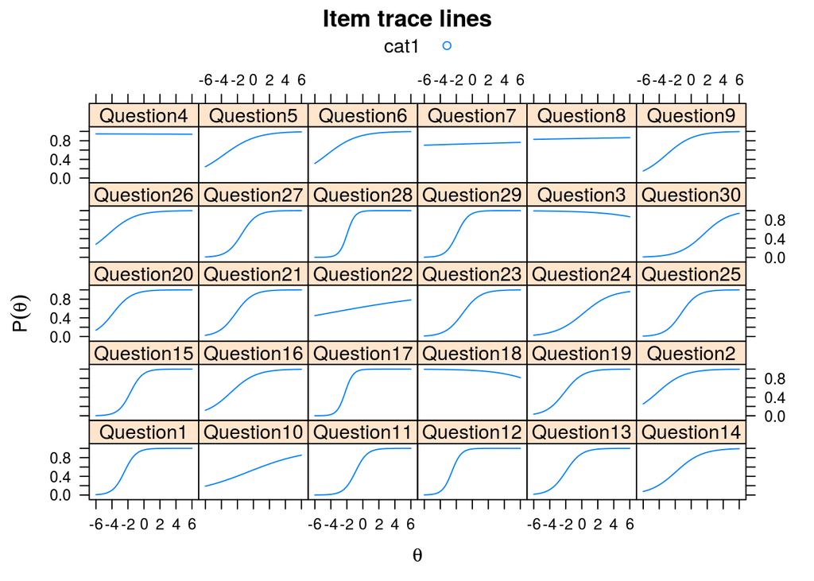

```r
plot(mod1, type = 'trace')
```

Plots of the Item Information Functions for all 30 items. The amount of information is influenced by the quality of the item.

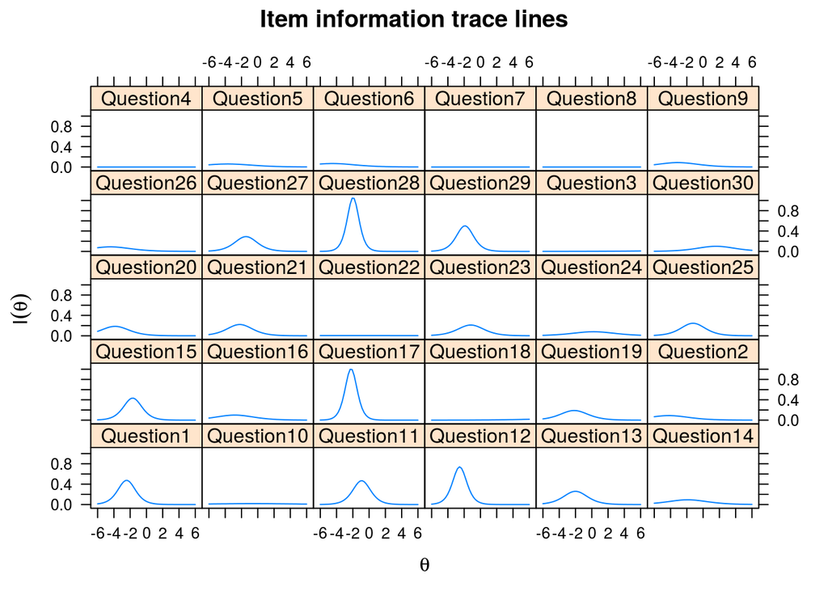

```r
plot(mod1, type='infotrace')
```

The Test Information Function combines the contributions from all Item Information Functions. Here, the amount of information is influenced both by the quality and by the number items.

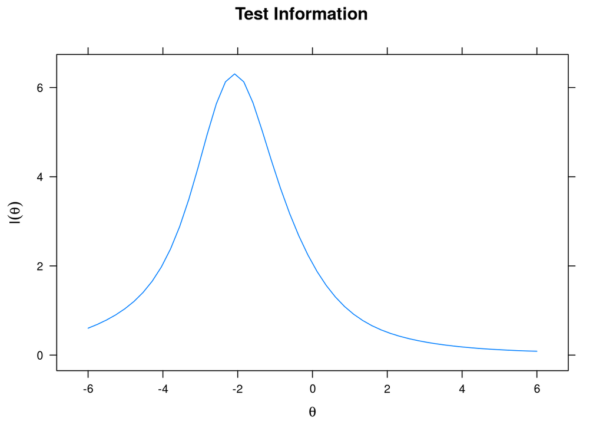

```r
plot(mod1)
```

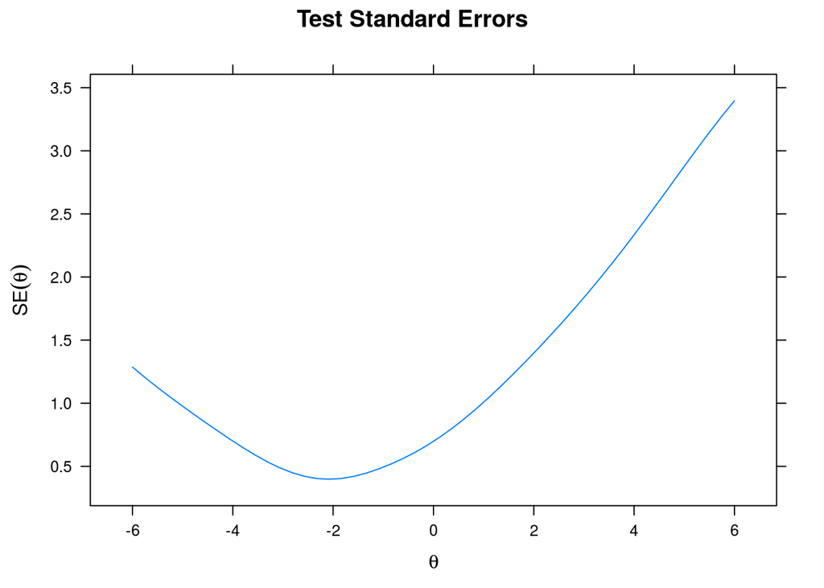

```r
plot(mod1, type='SE')
```

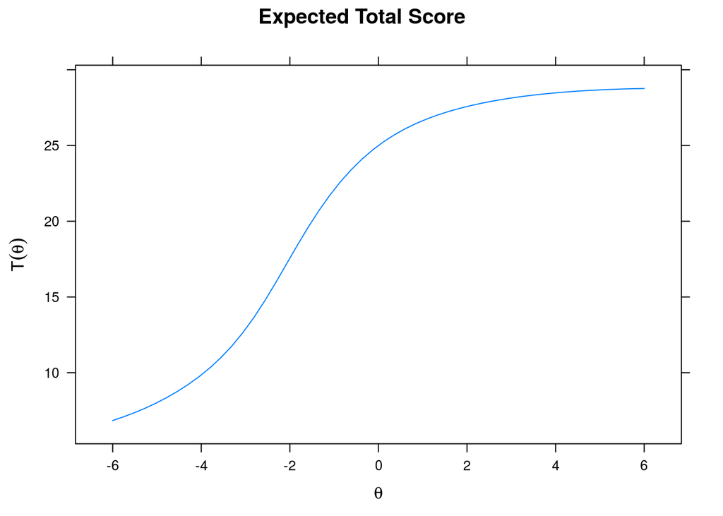

```r
plot(mod1, type='score')
```